# Practical Machine Learning course assignment

- Executive summary

- Data We downloaded the data from http://groupware.les.inf.puc-rio.br/har.

```r
library(caret)
setwd('C:/Users/Public/R/coursera/PML')
test<-read.csv('pml-testing.csv')
test<-read.csv('pml-testing.csv', na.string="NA")
train<-read.csv('pml-training.csv', na.string="NA")
#head(train)
```

A lot of variables have only NA values. Let us take a list

```r
g<-ls.str(train)
```

and shorten overall set of variables by omitting all variables having only NA or “#DIV/0!”/0 levels. We leave out all variables representing higher moments: “var”, “stdev” skewness" and “kurtosis”, as well as “amplitude”, “avg” and “min”, “max” variables.

```r
myvars <- names(train) %in% c(
"X", "user_name", "raw_timestamp_part_1", "raw_timestamp_part_2", "cvtd_timestamp", "new_window", "num_window",
"accel_arm_x", "accel_arm_y", "accel_arm_z", "accel_belt_x", "accel_belt_y", "accel_belt_z",
"accel_dumbbell_x", "accel_dumbbell_y", "accel_dumbbell_z", "accel_forearm_x", "accel_forearm_y", "accel_forearm_z",
"gyros_arm_x", "gyros_arm_y", "gyros_arm_z", "gyros_belt_x", "gyros_belt_y", "gyros_belt_z",
"gyros_dumbbell_x", "gyros_dumbbell_y", "gyros_dumbbell_z", "gyros_forearm_x", "gyros_forearm_y", "gyros_forearm_z",
"magnet_arm_x", "magnet_arm_y", "magnet_arm_z", "magnet_belt_x", "magnet_belt_y", "magnet_belt_z", "magnet_dumbbell_x",
"magnet_dumbbell_y", "magnet_dumbbell_z", "magnet_forearm_x", "magnet_forearm_y", "magnet_forearm_z",
"pitch_arm", "pitch_belt", "pitch_dumbbell", "pitch_forearm", "roll_arm", "roll_belt", "roll_dumbbell", "roll_forearm",
"total_accel_arm", "total_accel_belt", "total_accel_dumbbell", "total_accel_forearm",
"yaw_arm", "yaw_belt", "yaw_dumbbell", "yaw_forearm",
"classe")
newtrain <- train[myvars]
```

Next we add a few more variables about date and time when the excercise was performed, convert several variables to number (that data input automatically understood as factor), and rearrange data columns for easier prediction.

```r
newtrain$datetime<-strptime(as.character(newtrain$cvtd_timestamp), "%d/%m/%Y %H:%M")
newtrain$h.str <- as.numeric(format(newtrain$datetime, "%H")) + as.numeric(format(newtrain$datetime, "%M"))/60
newtrain$wd <- as.numeric(format(newtrain$datetime,"%w"))
newtrain$mth <- as.numeric(format(newtrain$datetime,"%m"))

newtrain$new_window<-ifelse(newtrain$new_window=="no",0,1)
trx<-newtrain[,c(6:59,62:64,60)]
#head(trx)
```

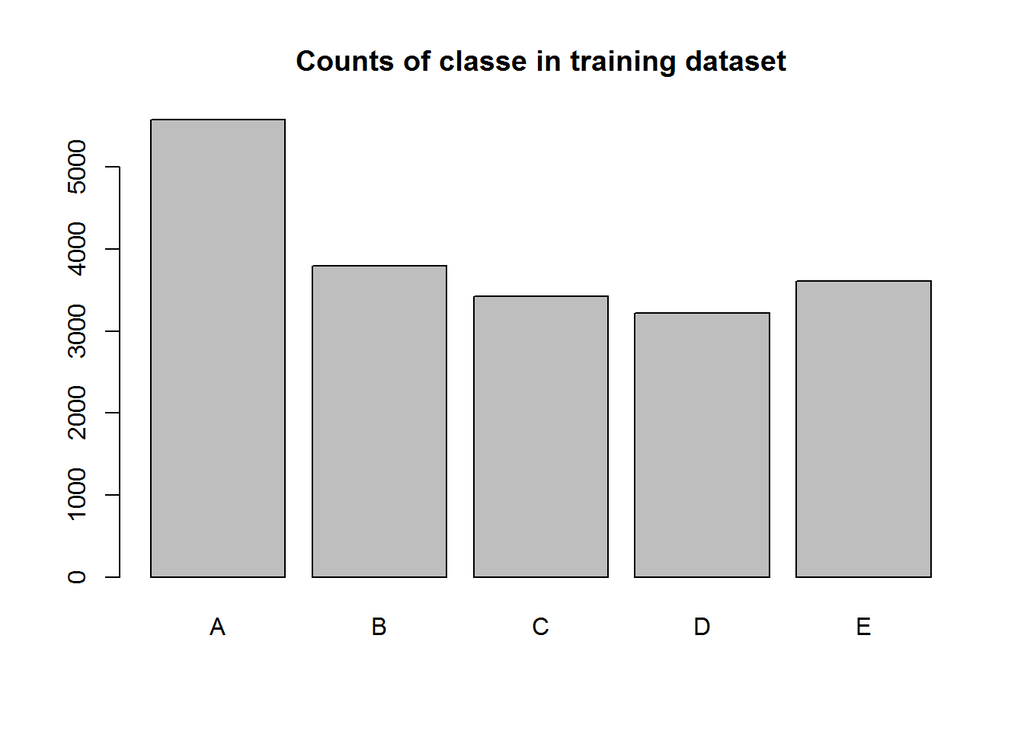

```r
x<-table(trx$classe)
barplot(x, main="Counts of classe in training dataset")
```

Next we split the data into testing and training datasets. Let us take only 20% of data into the training dataset because original dataset is large (19622 observations).

```r
set.seed(5541)
intrain<-createDataPartition(y=trx$classe, p=0.2,list=FALSE)
training<-trx[intrain,]
testing<-trx[-intrain,]
```

Let us run random forests algorithm from caret package. We will apply 5-fold cross validation.

```r
modFit_rf<-train(classe~. , data=training, method="rf", preProcess = c("center", "scale"), trControl=trainControl(method="cv",number=5))
modFit_rf
```

```
## Random Forest
##
## 3927 samples
##   57 predictor
##    5 classes: 'A', 'B', 'C', 'D', 'E'
##
## Pre-processing: centered, scaled
## Resampling: Cross-Validated (5 fold)
## Summary of sample sizes: 3142, 3140, 3142, 3142, 3142
## Resampling results across tuning parameters:
##
##   mtry  Accuracy   Kappa      Accuracy SD  Kappa SD
##    2    0.9686799  0.9603596  0.007666483  0.009721861
##   29    0.9837027  0.9793776  0.006942022  0.008787399
##   57    0.9806460  0.9755067  0.008374922  0.010605103
##
## Accuracy was used to select the optimal model using  the largest value.
## The final value used for the model was mtry = 29.
```

Prediction on testing dataset evaluates the power of random forest classification

```r
pred_rf<-predict(modFit_rf, testing)
table(pred_rf, testing$classe)
```

```
##
## pred_rf    A    B    C    D    E
##       A 4458   38    0    0    0
##       B    6 2981   73    0    5
##       C    0   18 2651   26    9
##       D    0    0   13 2535   36
##       E    0    0    0   11 2835
```

Let us also try boosting algorithm on the same data.

```r
modFit_ada<-train(classe~. , data=training, method="gbm", preProcess = c("center", "scale"), trControl=trainControl(method="cv",number=5), verbose=FALSE)
modFit_ada
```

```
## Stochastic Gradient Boosting
##
## 3927 samples
##   57 predictor
##    5 classes: 'A', 'B', 'C', 'D', 'E'
##
## Pre-processing: centered, scaled
## Resampling: Cross-Validated (5 fold)
## Summary of sample sizes: 3142, 3141, 3141, 3143, 3141
## Resampling results across tuning parameters:
##
##   interaction.depth  n.trees  Accuracy   Kappa      Accuracy SD
##   1                   50      0.7703024  0.7082744  0.016133539
##   1                  100      0.8462024  0.8053404  0.013801060
##   1                  150      0.8805785  0.8488813  0.010857427
##   2                   50      0.8976454  0.8704680  0.015031700
##   2                  100      0.9409273  0.9252491  0.009897982
##   2                  150      0.9587494  0.9478031  0.005578314
##   3                   50      0.9383831  0.9219980  0.009060991
##   3                  100      0.9640978  0.9545563  0.007035753
##   3                  150      0.9737745  0.9668164  0.005354529
##   Kappa SD
##   0.020587868
##   0.017274663
##   0.013545844
##   0.018976806
##   0.012521118
##   0.007055857
##   0.011453363
##   0.008902771
##   0.006771831
##
## Tuning parameter 'shrinkage' was held constant at a value of 0.1
##
## Tuning parameter 'n.minobsinnode' was held constant at a value of 10
## Accuracy was used to select the optimal model using  the largest value.
## The final values used for the model were n.trees = 150,
##  interaction.depth = 3, shrinkage = 0.1 and n.minobsinnode = 10.
```

```r
pred_ada<-predict(modFit_ada, testing)
table(pred_ada, testing$classe)
```

```
##
## pred_ada    A    B    C    D    E
##        A 4441   35    0    0    3
##        B   22 2970   84   14   23
##        C    1   31 2638   46    5
##        D    0    1   15 2489   37
##        E    0    0    0   23 2817
```

Accuracy of boosting model is slightly lower, 97.4%. Still it is very high and it confirms that models are able to discriminate very well betweent the quality of excersis. Accuracy of the random forest is close to perfect, therefore we will use random forest for predicting the original 20 test cases.

```r
print(modFit_rf$finalModel)
```

```
##
## Call:
##  randomForest(x = x, y = y, mtry = param$mtry)
##                Type of random forest: classification
##                      Number of trees: 500
## No. of variables tried at each split: 29
##
##         OOB estimate of  error rate: 1.45%
## Confusion matrix:
##      A   B   C   D   E  class.error
## A 1115   0   1   0   0 0.0008960573
## B   14 741   5   0   0 0.0250000000
## C    1  17 664   3   0 0.0306569343
## D    0   0  10 632   2 0.0186335404
## E    0   0   0   4 718 0.0055401662
```

```r
test<-read.csv('pml-testing.csv', na.string="NA")
#cut variable list
test <- test[myvars]
#transform data
test$datetime<-strptime(as.character(test$cvtd_timestamp), "%d/%m/%Y %H:%M")
test$h.str <- as.numeric(format(test$datetime, "%H")) + as.numeric(format(test$datetime, "%M"))/60
test$wd <- as.numeric(format(test$datetime,"%w"))
test$mth <- as.numeric(format(test$datetime,"%m"))
test$new_window<-as.numeric(ifelse(test$new_window=="no",0,1))
test<-test[,c(6:59,62:64,60)]
#make prediction
test$pred_rf_test<-predict(modFit_rf, test)
#output
test[names(test) %in% c("problem_id", "pred_rf_test")]
```

```
##    problem_id pred_rf_test
## 1           1            B
## 2           2            A
## 3           3            B
## 4           4            A
## 5           5            A
## 6           6            E
## 7           7            D
## 8           8            B
## 9           9            A
## 10         10            A
## 11         11            B
## 12         12            C
## 13         13            B
## 14         14            A
## 15         15            E
## 16         16            E
## 17         17            A
## 18         18            B
## 19         19            B
## 20         20            B
```